# Birds Documentation Process

Sandra Tobon

31/03/2020

# 1 Birds observation

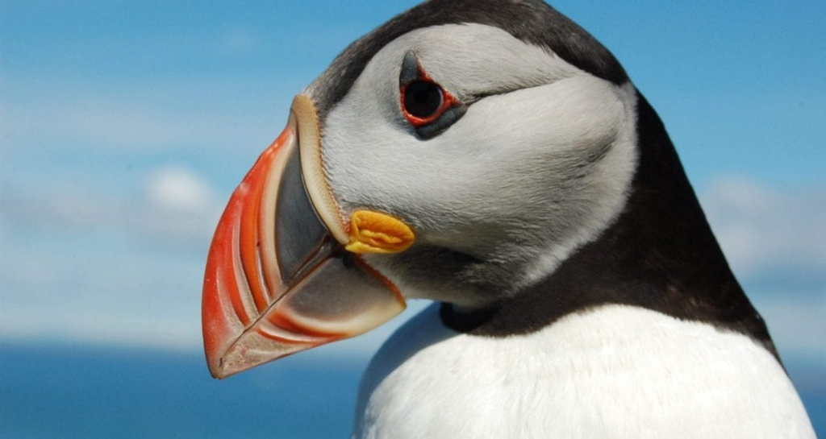

## 1.1 Explanation of the Data

The data is a recollection of observations of birds in 10 minutes from different ships.  
We have:

- the common, scientific and abreviation name of the species
- the amount of the same species saw in 10 minutes in count
- the latitude where the ship did the observation
- the id of the observation and one id for birds and ships

## 1.2 Clean process

- The data set have two tables, one for the birds observation and other for the ships that did the observation, the key that conect both table is record_id
- Both data set have a lot columns that have NULLS values and we don’t need for answering the questions so we have delete them
- We have keeped the columns accompanying_numbers or accompanying_ocurrence, because with them we can analyse if the birds were with accompanying or not at the moment of the view in different way that we do with the count column
- Both tables have an unique and numerical id
- We have droped the NULLS values
- We have inner join the tibbles by the record_id

## 1.3 Answers the Questions

1. Which bird had the most individual sightings?  
   Note: For answering this question we have answered with count column and with accompanying_ocurrence

```r
birds_ship_data %>%
  group_by(species_scientific_name, species_common_name, species_abbreviation) %>%
  filter(count == 1) %>%
  summarise(number_sightings = sum(count)) %>%
  arrange(desc(number_sightings)) %>%
  head(1)
```

| species_scientific_name | species_common_name | species_abbreviation | number_sightings |
| --- | --- | --- | --- |
| Diomedea antipodensis / exulans PL3 | Wandering albatross sensu lato PL3 | DIOANTEXU PL3 | 878 |

```r
birds_ship_data %>%
  group_by(species_scientific_name, species_common_name, species_abbreviation) %>%
  filter(count == 1, accompanying_ocurrence == "N") %>%
  summarise(number_sightings = sum(count)) %>%
  arrange(desc(number_sightings)) %>%
  head(1)
```

| species_scientific_name | species_common_name | species_abbreviation | number_sightings |
| --- | --- | --- | --- |
| Diomedea antipodensis / exulans PL3 | Wandering albatross sensu lato PL3 | DIOANTEXU PL3 | 786 |

2. Which bird had the highest total count?

```r
birds_ship_data %>%
  group_by(species_scientific_name, species_common_name, species_abbreviation) %>%
  summarise(number_total_sightings = sum(count)) %>%
  arrange(desc(number_total_sightings)) %>%
  head(1)
```

| species_scientific_name | species_common_name | species_abbreviation | number_total_sightings |
| --- | --- | --- | --- |
| Puffinus tenuirostris | Short-tailed shearwater | PUFTEN | 472580 |

3. Which bird had the highest total count above a latitude of -30?

```r
birds_ship_data %>%
  group_by(species_scientific_name, species_common_name, species_abbreviation) %>%
  filter(lat > -30) %>%
  summarise(number_total_sightings_30 = sum(count)) %>%
  arrange(desc(number_total_sightings_30)) %>%
  head(1)
```

| species_scientific_name | species_common_name | species_abbreviation | number_total_sightings_30 |
| --- | --- | --- | --- |
| Puffinus pacificus | Wedge-tailed shearwater | PUFPAC | 855 |

4. How many different types of birds were only ever seen in groups of 1?

```r
bird_view_one <- birds_ship_data %>%
  filter(count == 1)

bird_view_more <- birds_ship_data %>%
  filter(count >= 2)

bird_view_one %>%
  anti_join(bird_view_more, by = c("species_scientific_name",
   "species_common_name", "species_abbreviation")) %>%
  group_by(species_scientific_name, species_common_name, species_abbreviation) %>%
  summarise(real_species = n_distinct(species_common_name)) %>%
  nrow()
```

```
## [1] 103
```

5. How many penguins were seen?

```r
pattern = "[Pp]enguin"

birds_ship_data %>%
  filter(str_detect(species_common_name, pattern)) %>%
  summarise(total_penguin = sum(count))
```

| total_penguin |
| --- |
| 108 |